# Target Wins

Keeno Glanville

2023-09-05

# DATA EXPLORATION

Within this data set there are 2276 observations of 16 variables. The main focal point of this data is that we want to predict the target wins that a team will have over a given parameters.

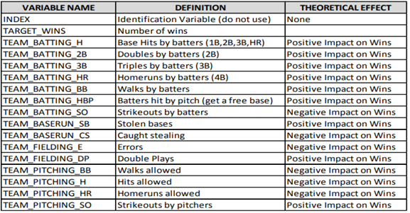

To first attack the data set there was some basic cleaning to remove the unnecessary naming within the columns. We then did some exploration summary of each column as well as the missing values within each. (ALL ACTIONS DONE TO TRAINING SETS DONE TO TESTING).

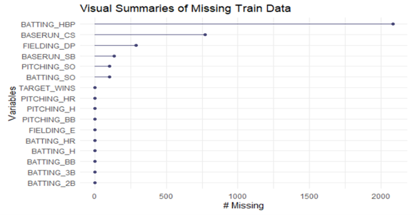

# DATA PREPARATION

In the preparation of the data for analysis I utilized various techniques to best decide how I would proceed with my analysis. One of these methods included creating a correlation heat map that would be essential in allowing me to better understand the data. This is significant because it would allow me to make a more informed decision as to what type of model I would create on the data set.

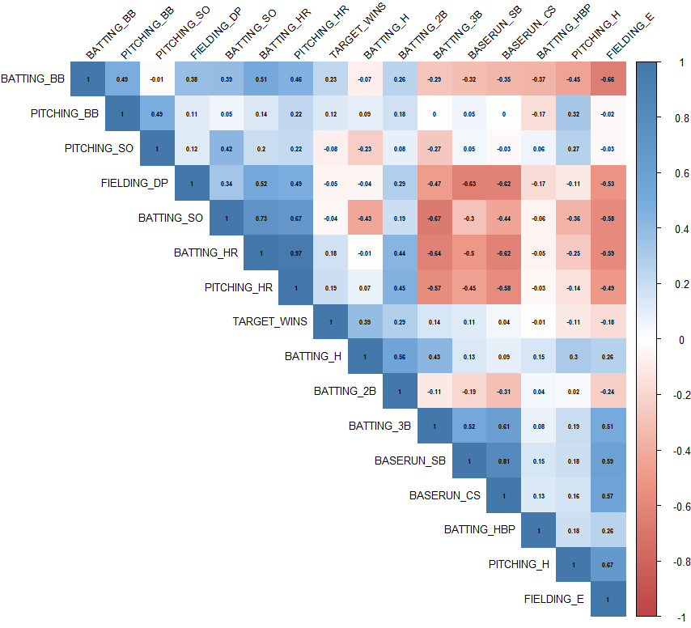

In continuation of preparation I utilized plots of all the variables against the target variable to see any specific linear relationships between them. Overall there weren’t very much direct linear relationships.

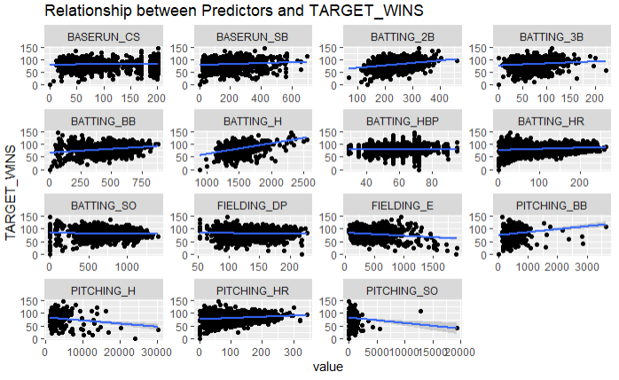

# BUILD MODELS

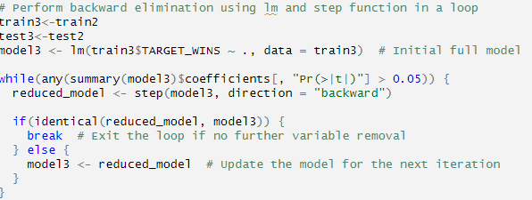

# SELECT MODELS

The model selection here we will go with will be the seceond model. In terms of selecting a model we will always go for the best performance because that should give us the best results in real world scenarios. We don’t want to be bias in our decision as it could hinder us going further. What we notice in the model however is that we didnt have a perfectly normal dataset through the residual plots. The Q-Q plot also showed various skewedness through the tailends. Overall this was similar throughout the models so through chosing the strong R-squared value we selected the model with the strongest predictor of future variables.

[figure not shown]

# APPENDIX

```r
library(tidyverse)
library(readxl)
library(dplyr)
library(naniar)
library(mice)
```

```r
library(corrplot)
library(ggplot2)
library(tidyr)
library(Metrics)
library(ggfortify)
set.seed(1234)
```

## Load Training and Testing data

```r
trainraw <- read_csv('https://raw.githubusercontent.com/kglan/MSDS/main/DATA621/Assignment1/moneyball-training-data.csv', col_names = TRUE)[,-1]
testraw <- read_csv('https://raw.githubusercontent.com/kglan/MSDS/main/DATA621/Assignment1/moneyball-evaluation-data.csv',col_names=TRUE)[,-1]
```

## Data Exploration

```r
dim(trainraw)
```

```
## [1] 2276   16
```

```r
head(trainraw)
```

```
## # A tibble: 6 × 16
##   TARGET_WINS TEAM_BATTING_H TEAM_BATTING_2B TEAM_BATTING_3B TEAM_BATTING_HR
##         <dbl>          <dbl>           <dbl>           <dbl>           <dbl>
## 1          39           1445             194              39              13
## 2          70           1339             219              22             190
## 3          86           1377             232              35             137
## 4          70           1387             209              38              96
## 5          82           1297             186              27             102
## 6          75           1279             200              36              92
## # ℹ 11 more variables: TEAM_BATTING_BB <dbl>, TEAM_BATTING_SO <dbl>,
## #   TEAM_BASERUN_SB <dbl>, TEAM_BASERUN_CS <dbl>, TEAM_BATTING_HBP <dbl>,
## #   TEAM_PITCHING_H <dbl>, TEAM_PITCHING_HR <dbl>, TEAM_PITCHING_BB <dbl>,
## #   TEAM_PITCHING_SO <dbl>, TEAM_FIELDING_E <dbl>, TEAM_FIELDING_DP <dbl>
```

```r
#Clean data headers and summarize
colnames(trainraw) <- gsub("TEAM_", "", colnames(trainraw))
colnames(testraw) <- gsub("TEAM_", "", colnames(testraw))
summary(trainraw)
```

```
##   TARGET_WINS       BATTING_H      BATTING_2B      BATTING_3B
##  Min.   :  0.00   Min.   : 891   Min.   : 69.0   Min.   :  0.00
##  1st Qu.: 71.00   1st Qu.:1383   1st Qu.:208.0   1st Qu.: 34.00
##  Median : 82.00   Median :1454   Median :238.0   Median : 47.00
##  Mean   : 80.79   Mean   :1469   Mean   :241.2   Mean   : 55.25
##  3rd Qu.: 92.00   3rd Qu.:1537   3rd Qu.:273.0   3rd Qu.: 72.00
##  Max.   :146.00   Max.   :2554   Max.   :458.0   Max.   :223.00
##
##    BATTING_HR       BATTING_BB      BATTING_SO       BASERUN_SB
##  Min.   :  0.00   Min.   :  0.0   Min.   :   0.0   Min.   :  0.0
##  1st Qu.: 42.00   1st Qu.:451.0   1st Qu.: 548.0   1st Qu.: 66.0
##  Median :102.00   Median :512.0   Median : 750.0   Median :101.0
##  Mean   : 99.61   Mean   :501.6   Mean   : 735.6   Mean   :124.8
##  3rd Qu.:147.00   3rd Qu.:580.0   3rd Qu.: 930.0   3rd Qu.:156.0
##  Max.   :264.00   Max.   :878.0   Max.   :1399.0   Max.   :697.0
##                                   NA's   :102      NA's   :131
##    BASERUN_CS     BATTING_HBP      PITCHING_H     PITCHING_HR
##  Min.   :  0.0   Min.   :29.00   Min.   : 1137   Min.   :  0.0
##  1st Qu.: 38.0   1st Qu.:50.50   1st Qu.: 1419   1st Qu.: 50.0
##  Median : 49.0   Median :58.00   Median : 1518   Median :107.0
##  Mean   : 52.8   Mean   :59.36   Mean   : 1779   Mean   :105.7
##  3rd Qu.: 62.0   3rd Qu.:67.00   3rd Qu.: 1682   3rd Qu.:150.0
##  Max.   :201.0   Max.   :95.00   Max.   :30132   Max.   :343.0
##  NA's   :772     NA's   :2085
##   PITCHING_BB      PITCHING_SO        FIELDING_E      FIELDING_DP
##  Min.   :   0.0   Min.   :    0.0   Min.   :  65.0   Min.   : 52.0
##  1st Qu.: 476.0   1st Qu.:  615.0   1st Qu.: 127.0   1st Qu.:131.0
##  Median : 536.5   Median :  813.5   Median : 159.0   Median :149.0
##  Mean   : 553.0   Mean   :  817.7   Mean   : 246.5   Mean   :146.4
##  3rd Qu.: 611.0   3rd Qu.:  968.0   3rd Qu.: 249.2   3rd Qu.:164.0
##  Max.   :3645.0   Max.   :19278.0   Max.   :1898.0   Max.   :228.0
##                   NA's   :102                        NA's   :286
```

```r
# Missing values
sapply(trainraw, function(x) sum(is.na(x)))
```

```
## TARGET_WINS   BATTING_H  BATTING_2B  BATTING_3B  BATTING_HR  BATTING_BB
##           0           0           0           0           0           0
##  BATTING_SO  BASERUN_SB  BASERUN_CS BATTING_HBP  PITCHING_H PITCHING_HR
##         102         131         772        2085           0           0
## PITCHING_BB PITCHING_SO  FIELDING_E FIELDING_DP
##           0         102           0         286
```

```r
sapply(testraw, function(x) sum(is.na(x)))
```

```
##   BATTING_H  BATTING_2B  BATTING_3B  BATTING_HR  BATTING_BB  BATTING_SO
##           0           0           0           0           0          18
##  BASERUN_SB  BASERUN_CS BATTING_HBP  PITCHING_H PITCHING_HR PITCHING_BB
##          13          87         240           0           0           0
## PITCHING_SO  FIELDING_E FIELDING_DP
##          18           0          31
```

Visualization of missing data

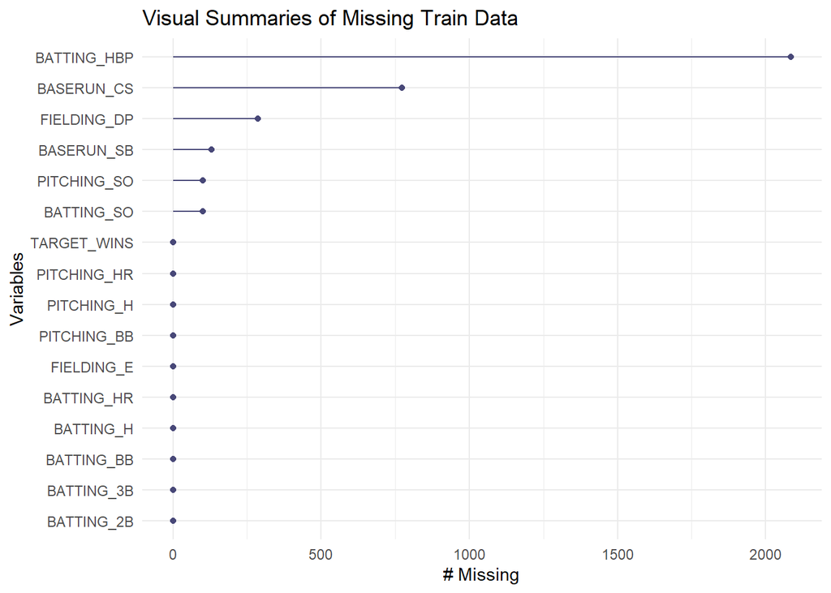

```r
gg_miss_var(trainraw)+ labs(title="Visual Summaries of Missing Train Data")
```

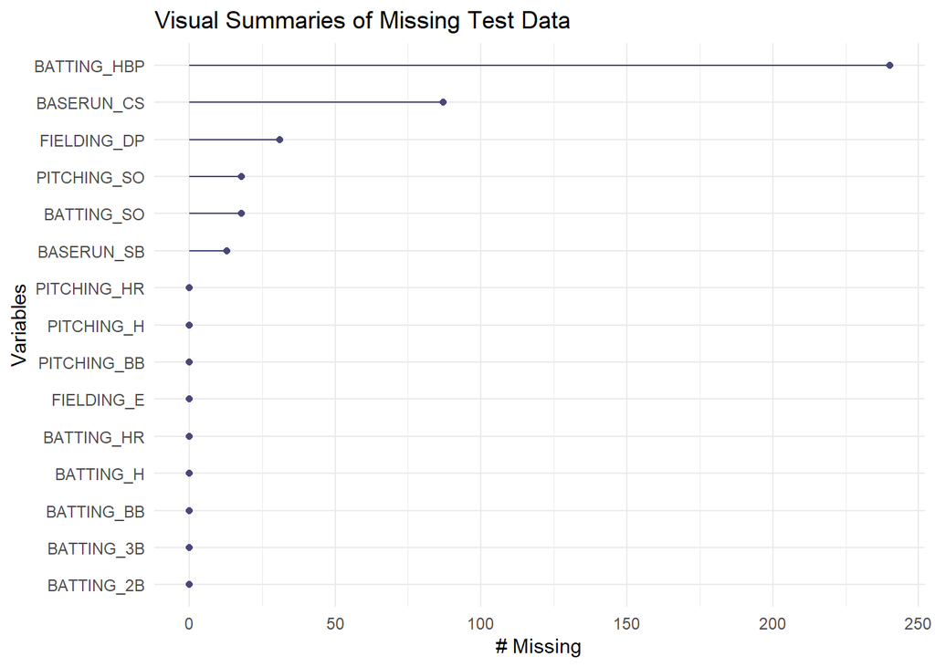

```r
gg_miss_var(testraw)+ labs(title="Visual Summaries of Missing Test Data")
```

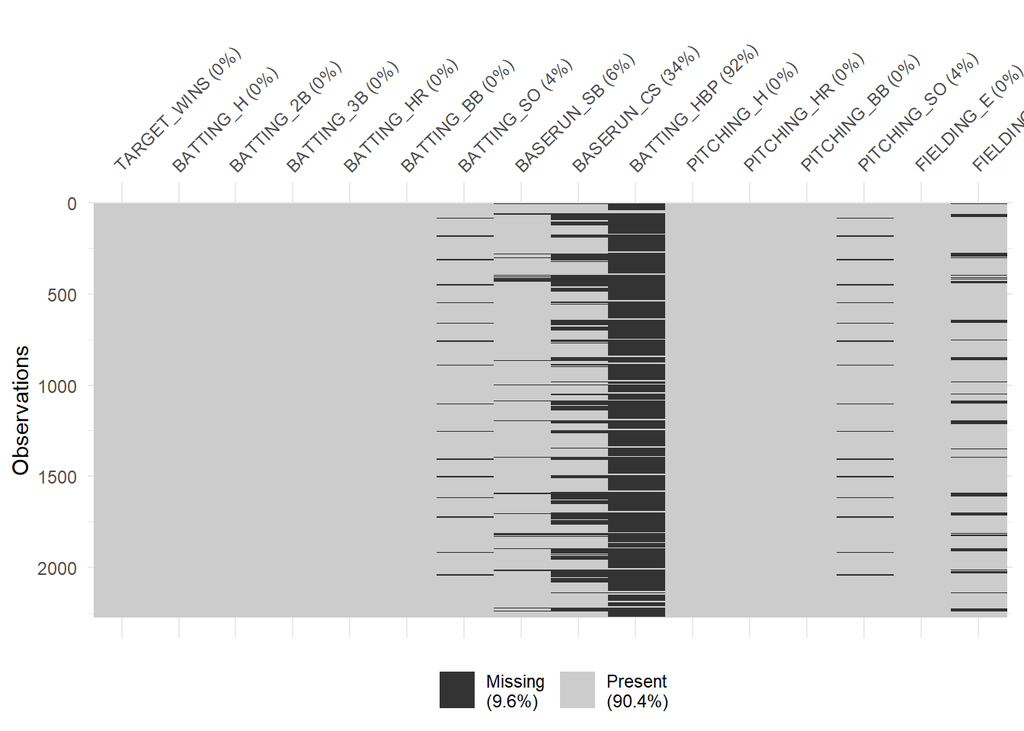

```r
vis_miss(trainraw)
```

## Data Preparation

### Imputation of Missing Values

```r
trainmice<- mice(trainraw, m = 5, method = "pmm", maxit = 50, seed = 123)
train<- complete(trainmice, action = 1)

testmice<- mice(testraw, m = 5, method = "pmm", maxit = 50, seed = 123)
test<- complete(testmice, action = 1)
```

```r
# Missing values
sapply(train, function(x) sum(is.na(x)))
```

```
## TARGET_WINS   BATTING_H  BATTING_2B  BATTING_3B  BATTING_HR  BATTING_BB
##           0           0           0           0           0           0
##  BATTING_SO  BASERUN_SB  BASERUN_CS BATTING_HBP  PITCHING_H PITCHING_HR
##           0           0           0           0           0           0
## PITCHING_BB PITCHING_SO  FIELDING_E FIELDING_DP
##           0           0           0           0
```

```r
sapply(test, function(x) sum(is.na(x)))
```

```
##   BATTING_H  BATTING_2B  BATTING_3B  BATTING_HR  BATTING_BB  BATTING_SO
##           0           0           0           0           0           0
##  BASERUN_SB  BASERUN_CS BATTING_HBP  PITCHING_H PITCHING_HR PITCHING_BB
##           0           0           0           0           0           0
## PITCHING_SO  FIELDING_E FIELDING_DP
##           0           0           0
```

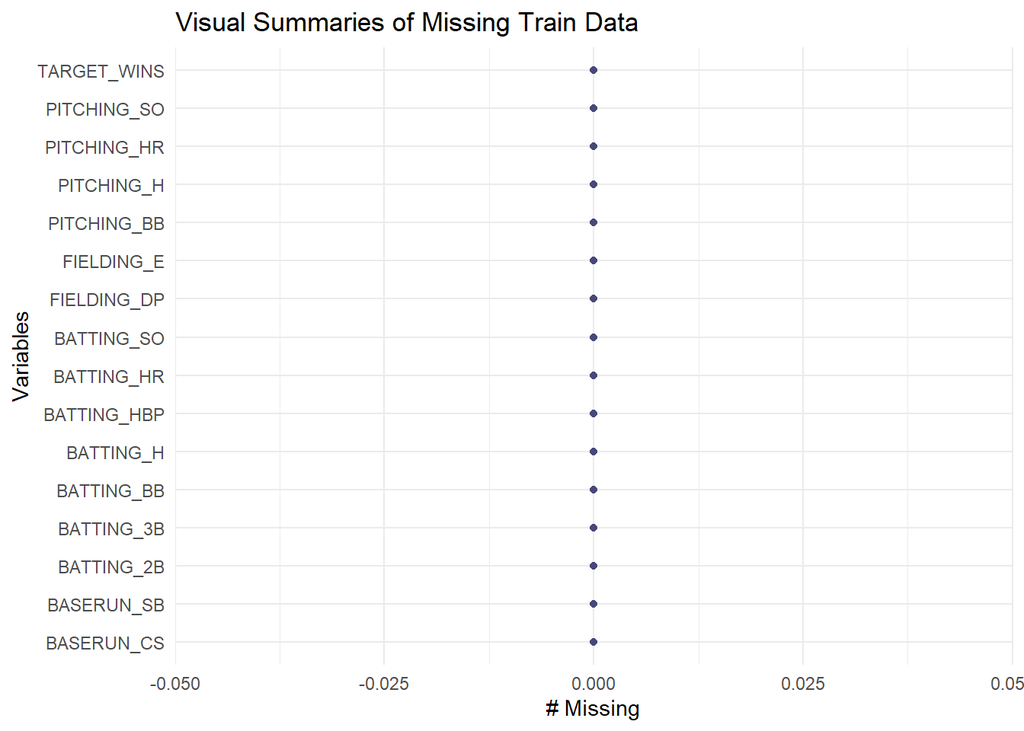

```r
gg_miss_var(train)+ labs(title="Visual Summaries of Missing Train Data")
```

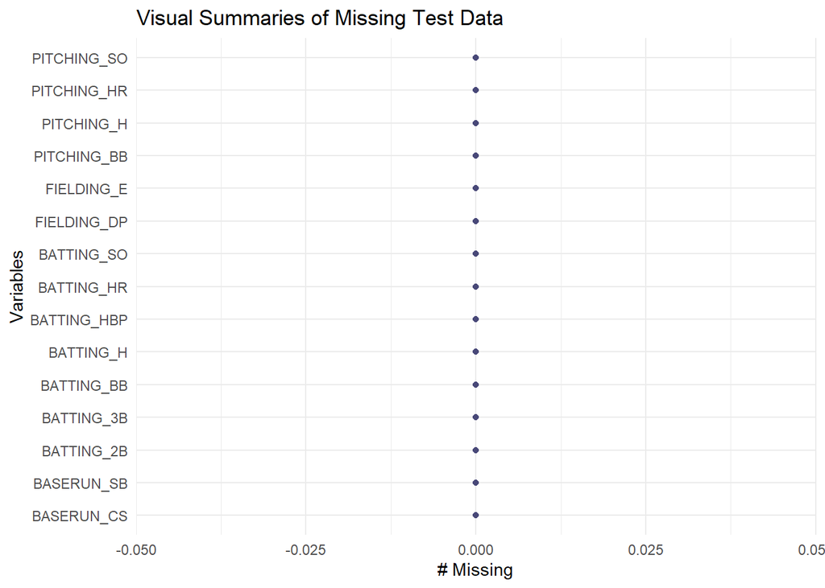

```r
gg_miss_var(test)+ labs(title="Visual Summaries of Missing Test Data")
```

### Visualization Utilizing Correlation Matrix

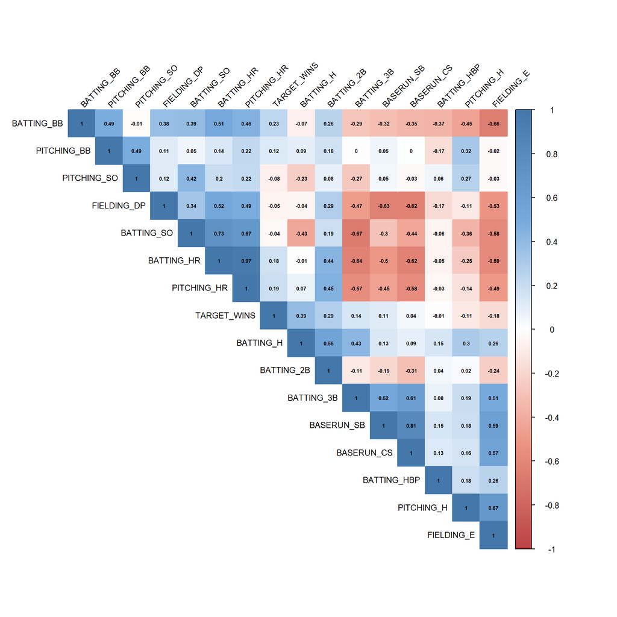

```r
# Find the correlation of the dataset
corplotdf <- cor(train, method = "pearson")
col_gd <- colorRampPalette(c("#BB4444", "#EE9988", "#FFFFFF", "#77AADD", "#4477AA"))

# Create the correlation plot
corrplot(corplotdf, method = "color", col = col_gd(200),
         type = "upper", order = "hclust",
         addCoef.col = "Black",
         tl.col = "black", tl.srt = 45, number.cex = 0.5, tl.cex = 0.8)
```

## Visualization of Boxplots

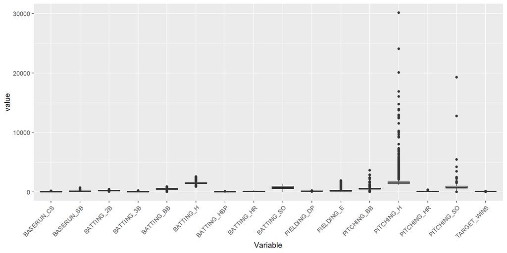

```r
# Create a boxplot for all columns
train_long <- gather(train)

# Create a boxplot for all columns
ggplot(train_long, aes(x = key, y = value)) +
  geom_boxplot() +
  xlab("Variable") +
  theme(axis.text.x = element_text(angle = 45, hjust = 1))
```

## Visualixation of plots of each variable to target variable

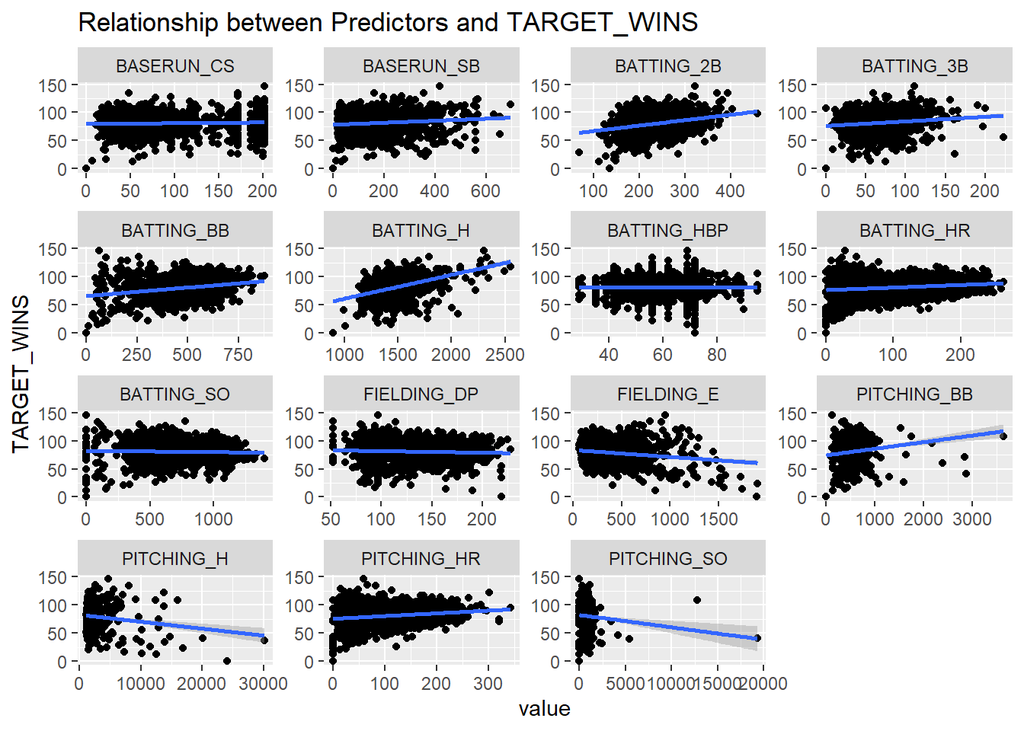

```r
train %>% gather(variable, value, -TARGET_WINS) %>% ggplot(., aes(value, TARGET_WINS))+geom_point()+geom_smooth(method="lm")+
  facet_wrap(~variable, scales="free")+ labs(title="Relationship between Predictors and TARGET_WINS")
```

## Build Models

### Model 1

Utilization of all variables to create initial model

```r
train1<-train
test1<-test
model1 <- lm(train1$TARGET_WINS ~ ., data = train1)
```

### Model 2

We will upgrade the first model by correcting the assumptions of normalization as well as scaling our data

```r
train2 <- train %>%
  mutate(across(
    c(PITCHING_BB, PITCHING_H, FIELDING_E, BASERUN_SB, BASERUN_CS),
    ~ log10(. + 1),
    .names = "log10_{.col}"
  )) %>%
  mutate_all(scale)

test2 <- test %>%
  mutate(across(
    c(PITCHING_BB, PITCHING_H, FIELDING_E, BASERUN_SB, BASERUN_CS),
    ~ log10(. + 1),
    .names = "log10_{.col}"
  )) %>%
  mutate_all(scale)


model2 <- lm(train2$TARGET_WINS ~ ., data = train2)
```

### Model3

We will use backward propagation to remove variables that are not significant to our data

```r
# Perform backward elimination using lm and step function in a loop
train3<-train2
test3<-test2
model3 <- lm(train3$TARGET_WINS ~ ., data = train3)  # Initial full model

while(any(summary(model3)$coefficients[, "Pr(>|t|)"] > 0.05)) {
  reduced_model <- step(model3, direction = "backward")

  if(identical(reduced_model, model3)) {
    break  # Exit the loop if no further variable removal
  } else {
    model3 <- reduced_model  # Update the model for the next iteration
  }
}
```

```
## Start:  AIC=-1075.58
## train3$TARGET_WINS ~ BATTING_H + BATTING_2B + BATTING_3B + BATTING_HR +
##     BATTING_BB + BATTING_SO + BASERUN_SB + BASERUN_CS + BATTING_HBP +
##     PITCHING_H + PITCHING_HR + PITCHING_BB + PITCHING_SO + FIELDING_E +
##     FIELDING_DP + log10_PITCHING_BB + log10_PITCHING_H + log10_FIELDING_E +
##     log10_BASERUN_SB + log10_BASERUN_CS
##
##                     Df Sum of Sq    RSS      AIC
## - log10_BASERUN_SB   1     0.031 1392.9 -1077.53
## - PITCHING_HR        1     0.151 1393.1 -1077.33
## - BATTING_HBP        1     0.470 1393.4 -1076.81
## - PITCHING_BB        1     0.759 1393.7 -1076.34
## - log10_BASERUN_CS   1     0.906 1393.8 -1076.10
## <none>                           1392.9 -1075.58
## - BASERUN_CS         1     1.765 1394.7 -1074.70
## - log10_PITCHING_BB  1     2.486 1395.4 -1073.52
## - BATTING_HR         1     4.075 1397.0 -1070.93
## - PITCHING_H         1     4.938 1397.8 -1069.53
## - PITCHING_SO        1     5.996 1398.9 -1067.80
## - BATTING_2B         1     6.569 1399.5 -1066.87
## - FIELDING_E         1    11.711 1404.6 -1058.52
## - BATTING_BB         1    11.735 1404.6 -1058.49
## - BATTING_3B         1    12.432 1405.3 -1057.36
## - log10_PITCHING_H   1    12.819 1405.7 -1056.73
## - log10_FIELDING_E   1    24.202 1417.1 -1038.38
## - BASERUN_SB         1    25.246 1418.2 -1036.70
## - BATTING_SO         1    28.597 1421.5 -1031.33
## - BATTING_H          1    40.109 1433.0 -1012.97
## - FIELDING_DP        1    59.019 1451.9  -983.13
##
## Step:  AIC=-1077.53
## train3$TARGET_WINS ~ BATTING_H + BATTING_2B + BATTING_3B + BATTING_HR +
##     BATTING_BB + BATTING_SO + BASERUN_SB + BASERUN_CS + BATTING_HBP +
##     PITCHING_H + PITCHING_HR + PITCHING_BB + PITCHING_SO + FIELDING_E +
##     FIELDING_DP + log10_PITCHING_BB + log10_PITCHING_H + log10_FIELDING_E +
##     log10_BASERUN_CS
##
##                     Df Sum of Sq    RSS      AIC
## - PITCHING_HR        1     0.153 1393.1 -1079.28
## - BATTING_HBP        1     0.471 1393.4 -1078.76
```

[output cut: 173 more lines]

```
## <none>                           1396.4 -1081.88
## - PITCHING_H         1     6.787 1403.2 -1072.85
## - BATTING_2B         1     7.148 1403.5 -1072.26
## - PITCHING_SO        1     7.361 1403.8 -1071.92
## - log10_PITCHING_BB  1    11.016 1407.4 -1066.00
## - FIELDING_E         1    11.523 1407.9 -1065.18
## - BATTING_3B         1    13.580 1410.0 -1061.86
## - log10_PITCHING_H   1    14.718 1411.1 -1060.02
## - BATTING_BB         1    16.181 1412.6 -1057.66
## - log10_FIELDING_E   1    24.862 1421.3 -1043.72
## - BATTING_HR         1    26.278 1422.7 -1041.45
## - BATTING_SO         1    30.839 1427.2 -1034.16
## - BATTING_H          1    49.094 1445.5 -1005.24
## - FIELDING_DP        1    62.057 1458.5  -984.92
## - BASERUN_SB         1   104.969 1501.4  -918.92
```

## Select Model

```r
summary(model1)
```

```
##
## Call:
## lm(formula = train1$TARGET_WINS ~ ., data = train1)
##
## Residuals:
##     Min      1Q  Median      3Q     Max
## -50.611  -8.405   0.183   8.350  49.893
##
## Coefficients:
##               Estimate Std. Error t value Pr(>|t|)
## (Intercept) 37.7807036  5.4263458   6.962 4.37e-12 ***
## BATTING_H    0.0406534  0.0035829  11.347  < 2e-16 ***
## BATTING_2B  -0.0171648  0.0088925  -1.930  0.05370 .
## BATTING_3B   0.0320047  0.0164104   1.950  0.05127 .
## BATTING_HR   0.0562249  0.0265651   2.116  0.03441 *
## BATTING_BB   0.0157857  0.0057439   2.748  0.00604 **
## BATTING_SO  -0.0180860  0.0025056  -7.218 7.16e-13 ***
## BASERUN_SB   0.0542331  0.0053219  10.190  < 2e-16 ***
## BASERUN_CS   0.0010569  0.0105330   0.100  0.92008
## BATTING_HBP  0.0139633  0.0264675   0.528  0.59785
## PITCHING_H   0.0013179  0.0003804   3.465  0.00054 ***
## PITCHING_HR  0.0298015  0.0235312   1.266  0.20548
## PITCHING_BB -0.0084897  0.0040249  -2.109  0.03503 *
## PITCHING_SO  0.0025014  0.0008957   2.793  0.00527 **
## FIELDING_E  -0.0422615  0.0026723 -15.815  < 2e-16 ***
## FIELDING_DP -0.1086123  0.0127585  -8.513  < 2e-16 ***
## ---
## Signif. codes:  0 '***' 0.001 '**' 0.01 '*' 0.05 '.' 0.1 ' ' 1
##
## Residual standard error: 12.6 on 2260 degrees of freedom
## Multiple R-squared:  0.3646, Adjusted R-squared:  0.3604
## F-statistic: 86.45 on 15 and 2260 DF,  p-value: < 2.2e-16
```

```r
summary(model2)
```

```
##
## Call:
## lm(formula = train2$TARGET_WINS ~ ., data = train2)
##
## Residuals:
##     Min      1Q  Median      3Q     Max
## -2.9636 -0.5108  0.0076  0.5124  3.4144
##
## Coefficients:
##                     Estimate Std. Error t value Pr(>|t|)
## (Intercept)       -6.331e-16  1.647e-02   0.000  1.00000
## BATTING_H          3.102e-01  3.850e-02   8.058 1.24e-15 ***
## BATTING_2B        -8.583e-02  2.632e-02  -3.261  0.00113 **
## BATTING_3B         1.351e-01  3.012e-02   4.486 7.61e-06 ***
## BATTING_HR         2.846e-01  1.108e-01   2.568  0.01028 *
## BATTING_BB         2.083e-01  4.779e-02   4.359 1.37e-05 ***
## BATTING_SO        -2.853e-01  4.193e-02  -6.804 1.30e-11 ***
## BASERUN_SB         3.295e-01  5.154e-02   6.393 1.97e-10 ***
## BASERUN_CS         1.116e-01  6.600e-02   1.690  0.09112 .
## BATTING_HBP        1.611e-02  1.847e-02   0.872  0.38322
## PITCHING_H        -1.387e-01  4.904e-02  -2.827  0.00473 **
## PITCHING_HR       -4.966e-02  1.004e-01  -0.495  0.62089
## PITCHING_BB       -6.037e-02  5.448e-02  -1.108  0.26787
## PITCHING_SO        9.765e-02  3.134e-02   3.116  0.00186 **
## FIELDING_E        -3.663e-01  8.412e-02  -4.354 1.39e-05 ***
## FIELDING_DP       -2.385e-01  2.440e-02  -9.775  < 2e-16 ***
## log10_PITCHING_BB -8.123e-02  4.049e-02  -2.006  0.04496 *
## log10_PITCHING_H   3.929e-01  8.624e-02   4.556 5.50e-06 ***
## log10_FIELDING_E  -5.012e-01  8.006e-02  -6.259 4.61e-10 ***
## log10_BASERUN_SB   1.177e-02  5.249e-02   0.224  0.82262
## log10_BASERUN_CS  -8.485e-02  7.008e-02  -1.211  0.22607
## ---
## Signif. codes:  0 '***' 0.001 '**' 0.01 '*' 0.05 '.' 0.1 ' ' 1
##
## Residual standard error: 0.7859 on 2255 degrees of freedom
## Multiple R-squared:  0.3877, Adjusted R-squared:  0.3823
## F-statistic:  71.4 on 20 and 2255 DF,  p-value: < 2.2e-16
```

```r
summary(model3)
```

```
##
## Call:
## lm(formula = train3$TARGET_WINS ~ BATTING_H + BATTING_2B + BATTING_3B +
##     BATTING_HR + BATTING_BB + BATTING_SO + BASERUN_SB + PITCHING_H +
##     PITCHING_SO + FIELDING_E + FIELDING_DP + log10_PITCHING_BB +
##     log10_PITCHING_H + log10_FIELDING_E, data = train3)
##
## Residuals:
##     Min      1Q  Median      3Q     Max
## -3.0721 -0.5162  0.0030  0.5221  3.4110
##
## Coefficients:
##                     Estimate Std. Error t value Pr(>|t|)
## (Intercept)       -5.916e-16  1.647e-02   0.000 1.000000
## BATTING_H          3.231e-01  3.624e-02   8.916  < 2e-16 ***
## BATTING_2B        -8.902e-02  2.617e-02  -3.402 0.000681 ***
## BATTING_3B         1.379e-01  2.940e-02   4.689 2.91e-06 ***
## BATTING_HR         2.426e-01  3.719e-02   6.523 8.48e-11 ***
## BATTING_BB         1.919e-01  3.748e-02   5.119 3.34e-07 ***
## BATTING_SO        -2.792e-01  3.952e-02  -7.066 2.11e-12 ***
## BASERUN_SB         3.522e-01  2.701e-02  13.037  < 2e-16 ***
## PITCHING_H        -1.480e-01  4.463e-02  -3.315 0.000931 ***
## PITCHING_SO        8.970e-02  2.598e-02   3.452 0.000566 ***
## FIELDING_E        -3.448e-01  7.982e-02  -4.319 1.63e-05 ***
## FIELDING_DP       -2.398e-01  2.392e-02 -10.024  < 2e-16 ***
## log10_PITCHING_BB -1.266e-01  2.997e-02  -4.223 2.50e-05 ***
## log10_PITCHING_H   3.553e-01  7.279e-02   4.882 1.13e-06 ***
## log10_FIELDING_E  -4.920e-01  7.755e-02  -6.345 2.68e-10 ***
## ---
## Signif. codes:  0 '***' 0.001 '**' 0.01 '*' 0.05 '.' 0.1 ' ' 1
##
## Residual standard error: 0.7859 on 2261 degrees of freedom
## Multiple R-squared:  0.3862, Adjusted R-squared:  0.3824
## F-statistic: 101.6 on 14 and 2261 DF,  p-value: < 2.2e-16
```

### Pre-Decision

Based on the information so far. Second model are tied for the most optimal models as they are the ones with the highest R squared values

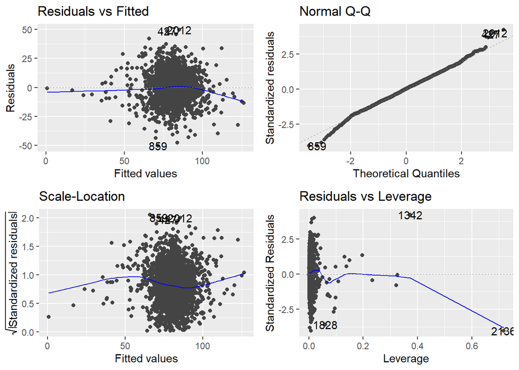

```r
autoplot(model1)
```

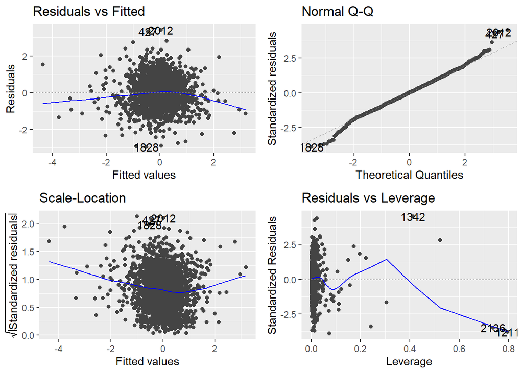

```r
autoplot(model2)
```

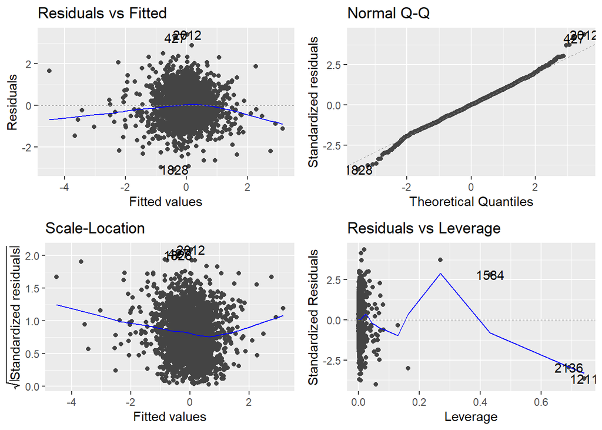

```r
autoplot(model3)
```

### Final Decision

The model selection here we will go with will be the seceond model. In terms of selecting a model we will always go for the best performance because that should give us the best results in real world scenarios. We don’t want to be bias in our decision as it could hinder us going further. What we notice in the model however is that we didnt have a perfectly normal dataset through the residual plots. The Q-Q plot also showed various skewedness through the tailends. Overall this was similar throughout the models so through chosing the strong R-squared value we selected the model with the strongest predictor of future variables.

Predictions

```r
# Prediction
predictions <- predict(model2, newdata = test2)

# Calculate Mean Squared Error (MSE)
mse <- mse(train2$TARGET_WINS, predictions)
# Calculate R-squared (R2) from the model summary
model_summary <- summary(model2)
r_squared <- model_summary$r.squared

# Print the evaluation metrics
cat("Mean Squared Error (MSE):", mse, "\n")
```

```
## Mean Squared Error (MSE): 1.524933
```

```r
cat("R-squared (R2):", r_squared, "\n")
```

```
## R-squared (R2): 0.3877344
```

```r
# Prediction( Failed Model 1)
predictions1 <- predict(model1, newdata = test1)

# Calculate Mean Squared Error (MSE)
mse <- mse(train1$TARGET_WINS, predictions1)
# Calculate R-squared (R2) from the model summary
model_summary <- summary(model1)
r_squared <- model_summary$r.squared

# Print the evaluation metrics
cat("Mean Squared Error (MSE):", mse, "\n")
```

```
## Mean Squared Error (MSE): 370.0858
```

```r
cat("R-squared (R2):", r_squared, "\n")
```

```
## R-squared (R2): 0.3645767
```

```r
# Prediction(Failed Model 3)
predictions <- predict(model3, newdata = test3)

# Calculate Mean Squared Error (MSE)
mse <- mse(train3$TARGET_WINS, predictions)
# Calculate R-squared (R2) from the model summary
model_summary <- summary(model3)
r_squared <- model_summary$r.squared

# Print the evaluation metrics
cat("Mean Squared Error (MSE):", mse, "\n")
```

```
## Mean Squared Error (MSE): 1.526187
```

```r
cat("R-squared (R2):", r_squared, "\n")
```

```
## R-squared (R2): 0.3861997
```